# RiDL group level timing checks

Michael Hallquist

20 Apr 2022

```r
#repo_dir <- "~/Data_Analysis/ridl_fmri_analysis"
#repo_dir <- "/proj/mnhallqlab/users/michael/ridl_fmri_analysis"
setwd("~/Data_Analysis/ridl_fmri_analysis/code")
pacman::p_load(dplyr, data.table, lattice, ggplot2, kableExtra, skimr)
options(digits=2)
ridl_dir <- normalizePath(file.path("../", "data", "momentum"))
source("parse_ridl.R")
source("parse_ridl_all.R")

matlab_dir <- "/System/Volumes/Data/Applications/MATLAB_R2021b.app/bin"

#helper function for printing tables in a consistent format
kable_table <- function(df, n=Inf, p=Inf) {
  p <- min(ncol(df), p)
  df %>% head(n=n) %>% dplyr::select(1:!!p) %>% kable() %>% kable_styling(bootstrap_options = c("striped", "condensed"), full_width = F)
}
```

```r
# read in data with ridl parser
# trial_df <- parse_ridl(sub_id = "220256", ridl_dir = ridl_dir, matlab_dir = matlab_dir)
# trial_df <- parse_ridl(sub_id = "221518", ridl_dir = ridl_dir, matlab_dir = matlab_dir, force=T)
# trial_df <- parse_ridl(sub_id = "540039", ridl_dir = ridl_dir, matlab_dir = matlab_dir, force=T)
# trial_df <- parse_ridl(sub_id = "221604", ridl_dir = ridl_dir, matlab_dir = matlab_dir, force=T)

trial_df <- parse_ridl_all(ridl_dir, matlab_dir = matlab_dir, force=FALSE) %>%
  mutate(was_slow = factor(times_too_slow > 0), was_slow_lead=factor(too_slow_lead > 0))
```

# Problems with missed trials

If a subject does not complete a trial, there is often a prepopulated row of all zeros. This seems to persist if the trial was never completed or if the block was repeated with a new data file (need to combine log_file.mat and log_file_0.mat?).

Two subjects have bad trials so far.

```r
trial_df %>% group_by(id) %>% tally(bad_trial) %>% filter(n > 0) %>% kable_table()
```

| id | n |
| --- | --- |
| 221518 | 55 |
| 440443 | 59 |

# Problems with low trial numbers

```r
trial_df %>% group_by(id) %>% tally() %>% filter(n < 336) %>% kable_table()
```

| id | n |
| --- | --- |
| 221518 | 168 |
| 440443 | 84 |
| 540001 | 84 |

I suspect there are two data files for these folks that need to be hand-stitched.

# Problem with rt = 0

Subjects with RTs < .05 seconds.

```r
zero_rt  <- trial_df %>% filter(reaction_time < .05)
zero_rt %>% xtabs(~id + trial_type, .)
```

```
##         trial_type
## id       accrej new_learn
##   221518      3         5
##   221817      0         1
##   540015      0         1
##   540032      0         2
```

```r
zero_rt %>% group_by(id, run_number) %>%
  select(id, run_number, trial, trial_type, block, choice, outcome, iti_ideal, reaction_time)  %>%
  filter(row_number() == 1) %>%
  kable_table()
```

| id | run_number | trial | trial_type | block | choice | outcome | iti_ideal | reaction_time |
| --- | --- | --- | --- | --- | --- | --- | --- | --- |
| 221518 | 1 | 63 | new_learn | 1002 | 1 | -1 | 2.0 | 0.05 |
| 221518 | 2 | 7 | accrej | 1003 | 0 | 0 | 2.0 | 0.04 |
| 221817 | 4 | 75 | new_learn | 1003 | 1 | -1 | 2.2 | 0.04 |
| 540015 | 3 | 69 | new_learn | 1002 | 1 | 1 | 2.7 | 0.02 |
| 540032 | 1 | 82 | new_learn | 1000 | 1 | 0 | 6.9 | 0.01 |

For now, dropping these trials. These may need to be added as nuisance trials in GLMs?

```r
trial_df <- trial_df %>% filter(reaction_time >= .05)
```

## Distribution of (good) RTs

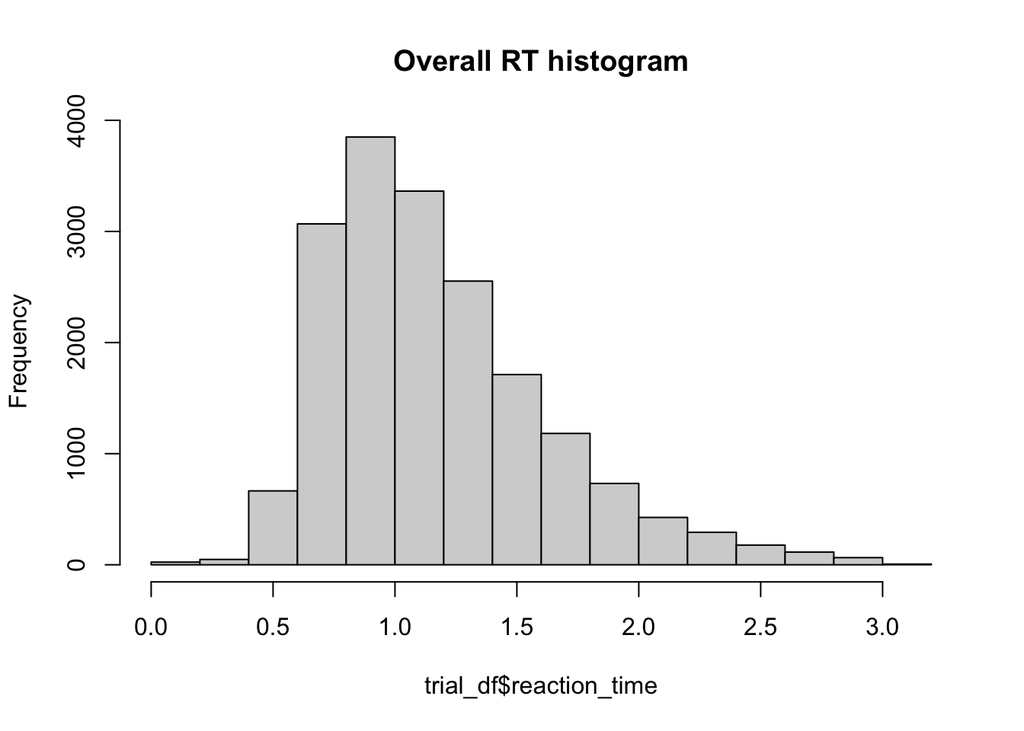

```r
hist(trial_df$reaction_time, main="Overall RT histogram")
```

# Expected versus observed RT times

Calculate the reaction time as `choice_time - stim_time` and compare to `reaction_time`.

This distribution generally looks reasonable, with 221604 showing a lot of differences in the .5s or greater range.

```r
# spot checks on timing
# expected versus observed RT
calc_rt <- trial_df$choice_time - trial_df$stim_time
trial_df$rt_diff <- trial_df$reaction_time - calc_rt
summary(trial_df$rt_diff) # looks reasonable
```

```
##    Min. 1st Qu.  Median    Mean 3rd Qu.    Max.
##   -0.11   -0.09    0.00   -0.03    0.00    1.03
```

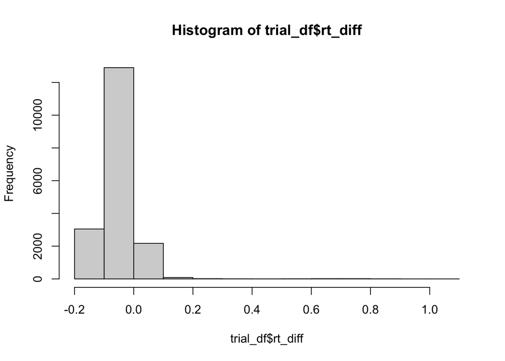

```r
hist(trial_df$rt_diff)
```

## by subject

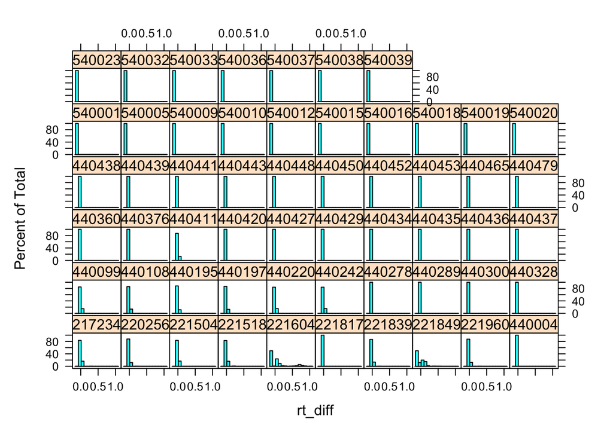

```r
lattice::histogram(~rt_diff | factor(id), trial_df)
```

## tally subjects with odd RTs

These are subjects who have differences in the reaction_time variable compared to the calculated reaction time. Check the `output/rt_diff_problems.csv` file for details

```r
bad_rt <- trial_df %>% filter(abs(rt_diff) > .2)
bad_rt %>% xtabs(~id, .)
```

```
## id
## 217234 220256 221518 221604 221839 221849 221960 440099 440108 440195 440197
##      1      1      1     52      1      4      1      1      1      1      1
## 440220 440242
##      1      1
```

```r
write.csv(bad_rt, file="../output/rt_diff_problems.csv", row.names=F)
```

# Expected versus observed feedback onset times

Here, we calculate the expected onset of theedback as `choice_time + feedback_isi` and compare that against the timestamp for `feedback_time` (recorded by the experiment). Most times are reasonable (< .2). There is a right tail with values between .2 and 2 seconds

My sense is that these resulted from some sort of stimulus loading or SQLite operation that induced variable (small) delays.

Note that the delays are heavily in the new_learn trials.

```r
# expected versus observed feedback onset
calc_feedback <- trial_df$choice_time + trial_df$feedback_isi # expected feedback onset time
trial_df$feedback_diff <- trial_df$feedback_time - calc_feedback

summary(trial_df$feedback_diff)
```

```
##    Min. 1st Qu.  Median    Mean 3rd Qu.    Max.
##    0.01    0.04    0.06    0.30    0.17    2.90
```

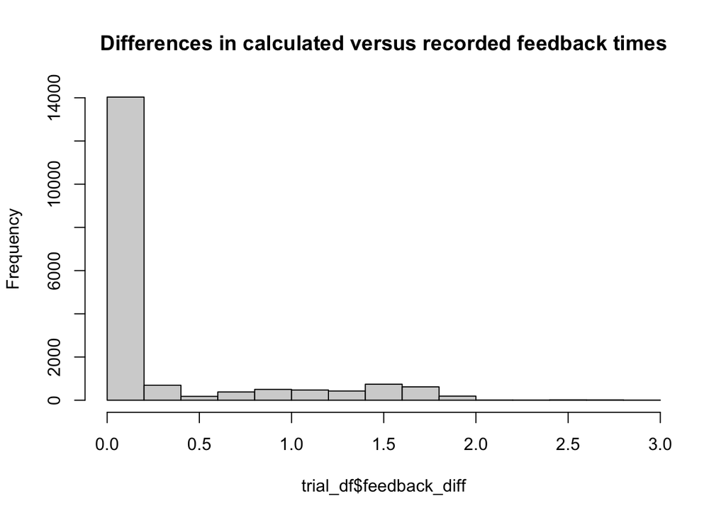

```r
hist(trial_df$feedback_diff, main="Differences in calculated versus recorded feedback times")
```

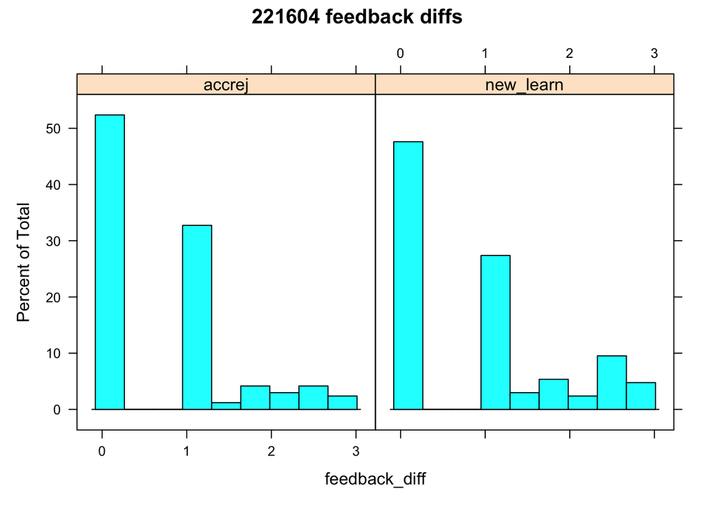

```r
# this was all due to 221604
#trial_df %>% filter(feedback_diff < 0) %>% kable_table()

# 221604 is an early Pitt subject (2021-05-17), but it appears that the feedback_time for new_learn trials was
# correct and did require the -1.0 timing correction. Adding this exception to parse_ridl.R (MNH 20Apr2022)
lattice::histogram(~feedback_diff | trial_type, trial_df %>% filter(id == 221604), main="221604 feedback diffs")
```

```r
# long delays in feedback display?
bad_feedback <- trial_df %>% filter(feedback_diff > .3)
write.csv(bad_feedback, file="../output/feedback_diff_problems.csv", row.names=F)

# too big
# trial_df %>% filter(feedback_diff > .5) %>% kable_table()

bad_feedback %>% xtabs(~id + trial_type, .)
```

```
##         trial_type
## id       accrej new_learn
##   217234      0        65
##   220256      0        65
##   221504      0        65
##   221518      0        18
##   221604     80        88
##   221817      0        64
##   221839      0        65
##   221849      0        68
##   221960      0        65
##   440004      0        64
##   440099      0        65
##   440108      0        65
##   440195      0        65
```

[output cut: 44 more lines]

# Expected versus observed onset times of next trial

The `trial_started_next` variable encodes the start time of the next trial: `trial_started_next = dplyr::lead(trial_started)`.

Note that in the original task version, if the subject was too slow, this was just recorded in `times_too_slow`, but only the final timing (of the good response) was retained. Thus, if `times_too_slow > 0`, then we should expect divergences in the calculated versus observed onset.

Importantly, though, we need to lead times_too_slow by 1 position to make it useful in calculating expected versus surprising timing divergences. That is, the expected onset of `feedback_time + 1` is based on the idea that the next trial starts on time and is completed without repeats (due to slowness). If slowness occurs, in early versions of the task (prior to March 2022), the row is replaced by the final repeat of the trial that the subject completed on time. Thus, the slowness of the next trial would lead the `trial_started_next` to diverge from `feedback_time + 1`.

Add 2.5 every 10 trials to the expected onset of the next trial to account for the 2.5 breaks

```r
# expected versus observed onset of next trial
# 1.0 is fixed duration of feedback event
trial_df$onset_diff <- trial_df$trial_started_next - (trial_df$feedback_time + 1.0 + 2.5*(trial_df$trial %% 10 == 0))
big_delays <- which(trial_df$onset_diff > 2)
# trial_df %>%
#   group_by(was_slow_lead) %>%
#   skim(onset_diff)

with(trial_df, tapply(onset_diff, was_slow_lead, summary))
```

```
## $`FALSE`
##    Min. 1st Qu.  Median    Mean 3rd Qu.    Max.
##    -8.6     0.0     0.1     0.1     0.1     1.0
##
## $`TRUE`
##    Min. 1st Qu.  Median    Mean 3rd Qu.    Max.
##       7       7       8      12      10     124
```

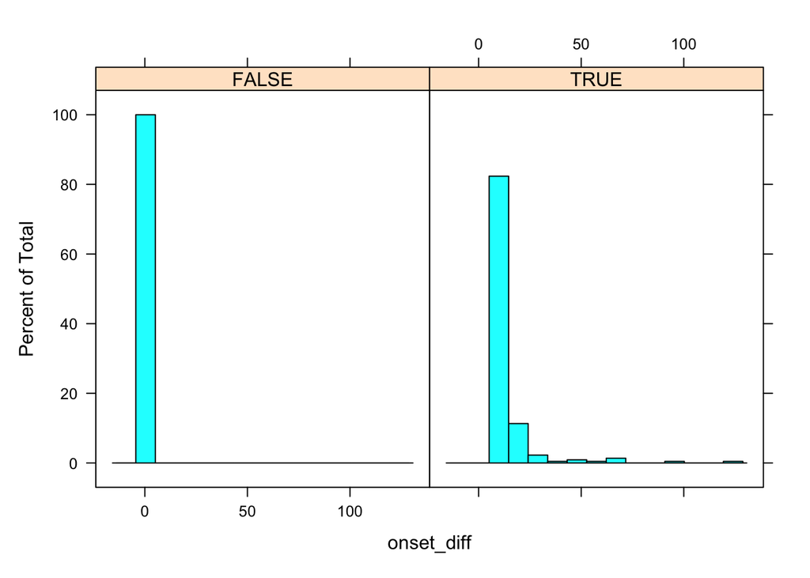

```r
lattice::histogram(~onset_diff | too_slow_lead > 0, trial_df)
```

```r
#trial_df %>% filter(onset_diff < -.1) %>% View()

#bad_subj <- trial_df %>% group_by(id) %>% summarize(has_delay = any(abs(onset_diff) > 20, na.rm=TRUE))
bad_onset <- trial_df %>% filter((abs(onset_diff) > .5 & was_slow_lead==FALSE) | (onset_diff > 20 | onset_diff < 0))
xtabs(~id + trial_type, bad_onset)
```

```
##         trial_type
## id       accrej new_learn
##   221518      5         1
##   221604     78        88
##   440360      0         1
##   440437      0         1
##   440439      1         2
##   440448      0         1
##   440450      0         1
##   440453      0         1
##   540005      2         0
##   540032      8         5
```

```r
write.csv(bad_onset, file="../output/onset_diff_problems.csv", row.names=F)
```

## More problems with 221604

```r
bad_subj <- trial_df %>% filter(id==221604) %>% mutate(neg_diff = onset_diff < 0)
table(bad_subj$too_slow_lead)
```

```
##
##   0   1
## 331   1
```

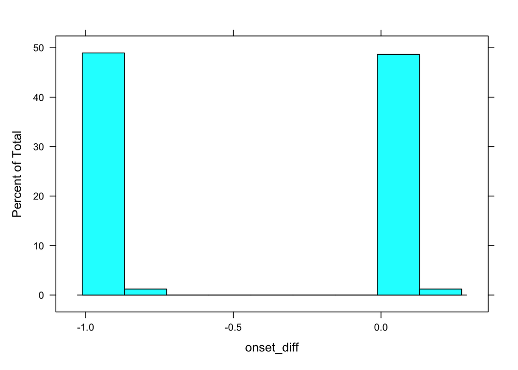

```r
lattice::histogram(~onset_diff, bad_subj %>% filter(too_slow_lead == 0))
```

```r
with(bad_subj, tapply(onset_diff, was_slow_lead, summary))
```

```
## $`FALSE`
##    Min. 1st Qu.  Median    Mean 3rd Qu.    Max.
##   -0.96   -0.92   -0.85   -0.42    0.09    0.23
##
## $`TRUE`
##    Min. 1st Qu.  Median    Mean 3rd Qu.    Max.
##     9.8     9.8     9.8     9.8     9.8     9.8
```

```r
xtabs(~trial_type + (onset_diff > 0), bad_subj)
```

```
##            onset_diff > 0
## trial_type  FALSE TRUE
##   accrej       78   86
##   new_learn    88   80
```

```r
#bad_subj %>% arrange(neg_diff, block, trial)
write.csv(bad_subj, file="../output/bad_timing_221604.csv", row.names=F)
```

## Expected delays after every 10 trials

Should be 2.5s break after every 10 trials, which is baked into onset_diff calculation above.

How many trials nevertheless have > .3 second differences? Minimal

```r
# Every 10 trials, the participant gets a 2.5s break
expected_delays <- which(trial_df$trial %% 10 == 0)
table(abs(trial_df$onset_diff[expected_delays]) > .3)
```

```
##
## FALSE  TRUE
##  1686    57
```

## Other delays

The remaining delays all appear to reflect trial repeats due to slowness on the next trial. The onset_time appears to be correct, but matches the onset of the final repeat in the case of initial slowness.

```r
# these trials are not on the every-10 trials, but have > 2s delays
weird_delays <- setdiff(big_delays, expected_delays)

# all of the unexpected delays occur on trials where the next trial was too slow
# thus, all of these delays are explained by the repetition of the trial (and this implies that the times in the file are the final presentation)

# the output here reflects the number of times that the next trial was repeated. A value of 0 would be truly unexplained delay
trial_df$too_slow_lead[weird_delays]
```

```
##   [1]  1  1  1  1  1  1  1  1  1  1  1  1  1  1  1  1  1  1  1  1  1  1  1  1  1
##  [26]  2  1  1  1  1  1  1  1  1  1  1  1  2  1  1  1  1  1  2  2  1 10  1  1  1
##  [51]  5  2  1  1  1  1  2 18  7  1  1  1  1  1  1  1  1  1  1  1  1  1  1  1  1
##  [76]  1  1  1  1  1  1  1  1  1  1  1  2  1  1  1  1  1  1  1  1  1  1  1  1  1
## [101]  1  1  1  1  1  1  1  2  1  2  1  1  1  1  1  1  1  1  1  1  1  2  1  1  1
## [126]  1  2  1  1  1  1  1  1  1  1  1  1  2  1  1  4  1  3 13  1  1  1  1  1  1
## [151]  1  1  1  1  1  1  1  1  1  1  1  1  4  1  2  1  4  8  3  3  1  5  1  2  1
## [176]  1  1  2  1  1  2  1  1  1  1  2  1  1  2  2  1  2  1  3  2  1  1  1  1  1
## [201]  1  1  4  2  3  1
```

```r
#trial_df %>% filter(times_too_slow > 0) %>% View()
```

## unexpected onset delays

```r
trial_df %>% filter(abs(onset_diff) > 2 & was_slow_lead == FALSE) %>%
  #group_by(id, run_number) %>%
  #filter(row_number() == 1L) %>%
  kable_table()
```

| id | run_number | trial | block | stim1 | stim2 | feedback | choice | outcome | times_too_slow | trial_started | iti_ideal_lag | stim_time | choice_time | reaction_time | correct_choice | feedback_isi | feedback_time | every_ten | experiment_date | experiment_build | site | trial_type | trial_started_next | stim_time_next | iti_ideal | too_slow_lead | bad_trial | outcome_fac | iti_actual | … |
| --- | --- | --- | --- | --- | --- | --- | --- | --- | --- | --- | --- | --- | --- | --- | --- | --- | --- | --- | --- | --- | --- | --- | --- | --- | --- | --- | --- | --- | --- | --- |
| 221518 | 2 | 1 | 1003 | 103 | -1000 | 0 | 1 | 0 | 0 | 2.6 | 2.3 | 4.9 | 5.4 | 0.47 | 0 | 2.2 | 7.6 | 0 | 2021-06-15 21:56:24 | 2-Feb-2021 | pitt | accrej | 0 | 0 | 0 | 0 | FALSE | nothing | -8.6 | … |

# ITI discrepancies

Difference in ideal versus actual ITIs. These seem to reflect the 2.5s breaks

If I follow the trial structure, would subjects see the 2.5s break stimulus immediately after feedback, then experience the following ITI?

Note that we should discount `iti_actual - iti_ideal` differences when the next trial was too slow since that will lead to onset delays that get attributed to the ITI.

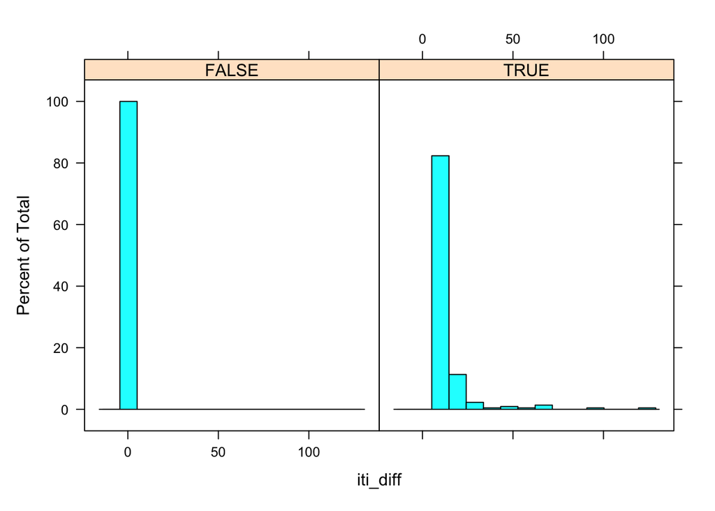

```r
trial_df$iti_diff <- trial_df$iti_actual - 2.5*(trial_df$trial %% 10 == 0) - trial_df$iti_ideal

lattice::histogram(~iti_diff | was_slow_lead, trial_df)
```

```r
with(trial_df %>% filter(was_slow_lead==FALSE), summary(iti_diff))
```

```
##    Min. 1st Qu.  Median    Mean 3rd Qu.    Max.
##    -8.6     0.1     0.1     0.1     0.2     1.2
```

```r
with(trial_df, tapply(iti_diff, was_slow_lead, summary))
```

```
## $`FALSE`
##    Min. 1st Qu.  Median    Mean 3rd Qu.    Max.
##    -8.6     0.1     0.1     0.1     0.2     1.2
##
## $`TRUE`
##    Min. 1st Qu.  Median    Mean 3rd Qu.    Max.
##       7       8       8      12      10     124
```

```r
#x <- trial_df %>% filter(abs(iti_diff) > .9 & was_slow_lead == FALSE)
#hist(x$iti_diff)
trial_df %>% filter(abs(iti_diff) > .9 & was_slow_lead == FALSE) %>%
  #group_by(id, run_number) %>%
  #filter(row_number() == 1L) %>%
  kable_table()
```

| id | run_number | trial | block | stim1 | stim2 | feedback | choice | outcome | times_too_slow | trial_started | iti_ideal_lag | stim_time | choice_time | reaction_time | correct_choice | feedback_isi | feedback_time | every_ten | experiment_date | experiment_build | site | trial_type | trial_started_next | stim_time_next | iti_ideal | too_slow_lead | bad_trial | outcome_fac | iti_actual | … |
| --- | --- | --- | --- | --- | --- | --- | --- | --- | --- | --- | --- | --- | --- | --- | --- | --- | --- | --- | --- | --- | --- | --- | --- | --- | --- | --- | --- | --- | --- | --- |
| 221518 | 2 | 1 | 1003 | 103 | -1000 | 0 | 1 | 0 | 0 | 2.6 | 2.3 | 4.9 | 5.4 | 0.47 | 0 | 2.2 | 7.6 | 0 | 2021-06-15 21:56:24 | 2-Feb-2021 | pitt | accrej | 0 | 0 | 0.0 | 0 | FALSE | nothing | -8.6 | … |
| 221604 | 1 | 4 | 1000 | 126 | -1000 | 0 | 0 | 1 | 0 | 31.8 | 2.1 | 34.8 | 36.9 | 2.78 | 0 | 4.5 | 41.5 | 0 | 2021-05-17 20:54:22 | 2-Feb-2021 | pitt | accrej | 43 | 47 | 3.2 | 0 | FALSE | win | 4.2 | … |
| 221604 | 1 | 44 | 1000 | 59 | -1000 | 1 | 1 | -1 | 0 | 397.4 | 4.2 | 401.9 | 403.8 | 1.95 | 1 | 2.9 | 406.8 | 0 | 2021-05-17 20:54:22 | 2-Feb-2021 | pitt | new_learn | 408 | 412 | 3.4 | 0 | FALSE | loss | 4.4 | … |
| 221604 | 2 | 6 | 1001 | 36 | -1000 | 0 | 0 | 1 | 0 | 50.1 | 5.3 | 56.2 | 57.7 | 2.10 | 0 | 4.7 | 62.4 | 0 | 2021-05-17 20:54:22 | 2-Feb-2021 | pitt | accrej | 64 | 67 | 2.1 | 0 | FALSE | win | 3.2 | … |
| 221604 | 2 | 10 | 1001 | 29 | -1000 | 0 | 0 | -1 | 0 | 88.5 | 2.0 | 91.4 | 92.6 | 1.96 | 1 | 4.5 | 97.3 | 98 | 2021-05-17 20:54:22 | 2-Feb-2021 | pitt | accrej | 101 | 105 | 3.5 | 0 | FALSE | loss | 7.1 | … |
| 221604 | 2 | 25 | 1001 | 95 | -1000 | 1 | 0 | 1 | 0 | 226.4 | 2.8 | 229.5 | 231.1 | 1.61 | 1 | 4.6 | 235.7 | 0 | 2021-05-17 20:54:22 | 2-Feb-2021 | pitt | new_learn | 237 | 242 | 4.7 | 0 | FALSE | win | 5.7 | … |
| 221604 | 2 | 31 | 1001 | 97 | -1000 | 1 | 0 | 1 | 0 | 280.2 | 1.9 | 282.9 | 283.9 | 1.62 | 1 | 4.4 | 288.4 | 0 | 2021-05-17 20:54:22 | 2-Feb-2021 | pitt | new_learn | 289 | 293 | 2.2 | 0 | FALSE | win | 3.2 | … |
| 221604 | 2 | 51 | 1001 | 69 | -1000 | 1 | 0 | -1 | 0 | 465.1 | 2.0 | 467.5 | 468.7 | 1.37 | 0 | 5.1 | 473.9 | 0 | 2021-05-17 20:54:22 | 2-Feb-2021 | pitt | new_learn | 475 | 478 | 2.2 | 0 | FALSE | loss | 3.4 | … |
| 221604 | 2 | 59 | 1001 | 23 | -1000 | 0 | 0 | -1 | 0 | 544.7 | 2.5 | 547.5 | 548.5 | 1.09 | 1 | 4.2 | 552.9 | 0 | 2021-05-17 20:54:22 | 2-Feb-2021 | pitt | accrej | 554 | 560 | 4.5 | 0 | FALSE | loss | 5.7 | … |
| 221604 | 2 | 67 | 1001 | 183 | 185 | 1 | 1 | 1 | 0 | 625.5 | 1.8 | 627.4 | 628.7 | 1.27 | 1 | 4.4 | 634.2 | 0 | 2021-05-17 20:54:22 | 2-Feb-2021 | pitt | new_learn | 634 | 638 | 3.5 | 0 | FALSE | win | 2.5 | … |
| 221604 | 2 | 70 | 1001 | 106 | -1000 | 0 | 0 | 1 | 0 | 652.6 | 4.3 | 657.2 | 658.2 | 1.04 | 1 | 4.2 | 662.4 | 663 | 2021-05-17 20:54:22 | 2-Feb-2021 | pitt | accrej | 666 | 671 | 4.1 | 0 | FALSE | win | 7.5 | … |
| 221604 | 4 | 35 | 1003 | 73 | -1000 | 0 | 0 | 0 | 0 | 311.9 | 2.1 | 314.5 | 315.5 | 1.30 | 1 | 2.8 | 318.4 | 0 | 2021-05-17 20:54:22 | 2-Feb-2021 | pitt | accrej | 320 | 322 | 1.8 | 0 | FALSE | nothing | 3.0 | … |
| 221604 | 4 | 57 | 1003 | 191 | 189 | 1 | 0 | 1 | 0 | 501.3 | 5.0 | 506.4 | 507.4 | 0.85 | 1 | 1.0 | 511.0 | 0 | 2021-05-17 20:54:22 | 2-Feb-2021 | pitt | new_learn | 511 | 514 | 2.7 | 0 | FALSE | win | 1.8 | … |
| 221604 | 4 | 75 | 1003 | 189 | 191 | 1 | 1 | -1 | 0 | 673.5 | 5.0 | 678.6 | 679.6 | 0.94 | 1 | 5.0 | 685.6 | 0 | 2021-05-17 20:54:22 | 2-Feb-2021 | pitt | new_learn | 686 | 688 | 2.2 | 0 | FALSE | loss | 1.3 | … |
| 221849 | 4 | 35 | 1003 | 67 | -1000 | 0 | 0 | 0 | 0 | 310.3 | 2.1 | 312.6 | 313.8 | 1.17 | 1 | 2.8 | 316.7 | 0 | 2021-05-18 21:58:41 | 2-Feb-2021 | pitt | accrej | 318 | 321 | 1.8 | 0 | FALSE | nothing | 2.8 | … |
| 540005 | 3 | 13 | 1002 | 67 | -1000 | 0 | 0 | 1 | 0 | 116.7 | 2.3 | 119.0 | 120.3 | 1.16 | 1 | 3.0 | 123.3 | 0 | 2021-10-11 23:24:35 | 2-Feb-2021 | unc | accrej | 125 | 127 | 1.9 | 0 | FALSE | win | 3.0 | … |

# Export data to file

```r
# write to file
fwrite(trial_df, file=file.path("../", "output", "ridl_combined.csv.gz"))
```

# Prepare data for GLMs

```r
trial_df_fmri <- trial_df %>% select(
  id, run_number, trial, trial_type, outcome_fac,
  stim_time, choice_time, reaction_time, feedback_time, feedback_isi, iti_actual
) %>%
  rename(choice_onset = stim_time, feedback_onset = feedback_time) %>%
  mutate(feedback_duration = 1.0)


xtabs(~outcome_fac + trial_type, trial_df_fmri)
```

```
##            trial_type
## outcome_fac accrej new_learn
##     loss      3211      2453
##     nothing   1752      1822
##     win       4188      4850
```

```r
fwrite(trial_df_fmri, file=file.path("../", "output", "ridl_combined_fmri.csv.gz"))
```